# Experiment

### Prerequisites

**Imports**

```python
import os
import sys
import warnings
import numpy as np
import geopandas as gpd
from shapely.geometry import Polygon, LineString, MultiLineString
import pykrige.kriging_tools as kt
from pykrige.ok import OrdinaryKriging
import matplotlib.pyplot as plt
```

**Fix directories, define path variables**

```python
# make sure notebook is ran from src
cwd = os.getcwd()
if not cwd.split(os.sep)[-1] == 'src':
    try:
        os.chdir('src')
    except FileNotFoundError:
        print('Error: please run from src dir or project root')
        sys.exit(1)

# define paths
data_path = '../data/'
path = lambda x: os.path.join(*x.split('/')) + os.sep
data_path = path('../data')
csv_path = path('../data/csv')
shp_path = path('../data/shapefiles')
plot_path = path('../plots')
if not os.path.exists(plot_path):
    os.mkdir(plot_path)
```

**Read data**

```python
# these are just manhattan gdfs, with correct projection
STREETS: gpd.GeoDataFrame = gpd.read_file(shp_path + 'streets' + os.sep + 'M_streets.shp')
TRAFFIC: gpd.GeoDataFrame = gpd.read_file(shp_path + 'traffic' + os.sep + 'M_traffic.shp')
TREES: gpd.GeoDataFrame = gpd.read_file(shp_path + 'trees' + os.sep + 'M_trees.shp')
```

**Set Random Seed**

```python
seed = 2112
np.random.seed(seed)
```

### Grid Setup

**Create grid**

```python
# define a bounding box around Manhattan
xmin, ymin, xmax, ymax = STREETS.total_bounds
bbox = Polygon([(xmin, ymin), (xmin, ymax), (xmax, ymax), (xmax, ymin)])

# define granularity of grid (units are degrees [EPSG:4326])
l, w = .005, .005

# create a grid of polygons
cols = list(np.arange(xmin, xmax+w, w))
rows = list(np.arange(ymin, ymax+l, l))
polygons = []
for x in cols[:-1]:
    for y in rows[:-1]:
        polygons.append(Polygon([(x, y), (x, y+l), (x+w, y+l), (x+w, y), (x, y)]))

# create a gdf from the grid
GRID = gpd.GeoDataFrame({'geometry': polygons})
GRID.crs = 4326

# remove grid cells that do not intersect with any street
size_before = GRID.shape[0]
GRID = GRID[GRID.intersects(STREETS.unary_union)]
GRID = GRID.reset_index(drop=True)
print(f'Grid cells trimmed to {GRID.shape[0]} from {size_before}')
```

```
Grid cells trimmed to 393 from 1040
```

**Assign "easy" values to grid**

```python
# we would get a SettingWithCopyWarning, but it's not a problem
with warnings.catch_warnings():
    warnings.simplefilter('ignore')
    # number of trees within grid cell
    GRID['n_trees'] = GRID.geometry.apply(lambda x: TREES[TREES.geometry.within(x)].shape[0])
    # average of all traffic volume probes within grid cell
    GRID['trfc_raw'] = GRID.geometry.apply(lambda x: TRAFFIC[TRAFFIC.geometry.within(x)].Avg_Vol.mean())
```

**Plot to check**

```python
# this dict will be used later as well, so we define all titles here
titles: dict[str] = {
    'n_trees': 'Number of Trees',
    'trfc_raw': 'Traffic Volume (raw)',
    'tree_dist': 'Average Distance between Trees',
    'tree_distl': 'Average Distance between Trees (log)',
    'street_len': 'Street Length per Grid Cell',
    'trfc_itp': 'Traffic Volume (interpolated)',
}
```

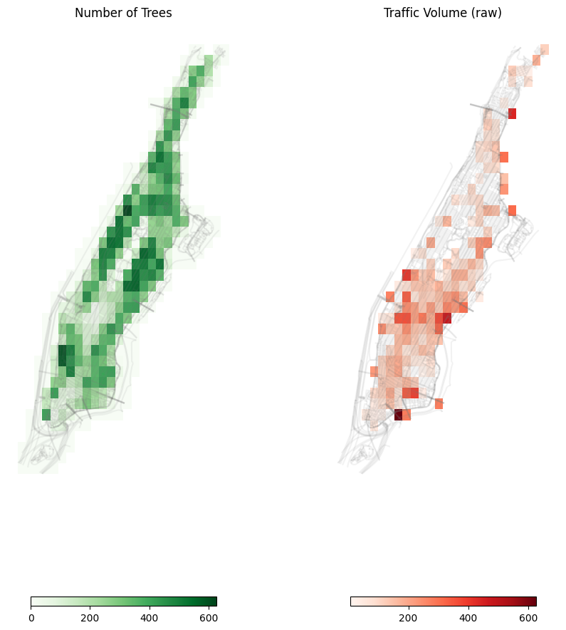

```python
fig, (ax1, ax2) = plt.subplots(1, 2, figsize=(10, 10))
for ax, col, cmap in zip([ax1, ax2], ['n_trees', 'trfc_raw'], ['Greens', 'Reds']):
    GRID.plot(ax=ax, column=col, cmap=cmap, legend=True, zorder=1, legend_kwds={'orientation': 'horizontal', 'shrink': 0.5})
    STREETS.plot(ax=ax, color='grey', alpha=0.1, zorder=2)
    ax.set_axis_off()
    ax.set_title(titles[col])
fig.tight_layout()
fig.savefig(plot_path + 'grid_raw.png', dpi=500)
```

### Street lengths per grid cell

**Define `haversine` function**

```python
def haversine(p1: tuple[float], p2: tuple[float]) -> float:
    """ Calculate the great circle distance in meters between two points on the earth. """
    # convert decimal degrees to radians
    lon1, lat1, lon2, lat2 = map(np.radians, [p1[0], p1[1], p2[0], p2[1]])
    # haversine formula
    dlon = lon2 - lon1
    dlat = lat2 - lat1
    a = np.sin(dlat/2)**2 + np.cos(lat1) * np.cos(lat2) * np.sin(dlon/2)**2
    c = 2 * np.arcsin(np.sqrt(a))
    r = 6371  # radius of earth in kilometers
    return c * r * 1000
```

**Calculate total street length per cell**

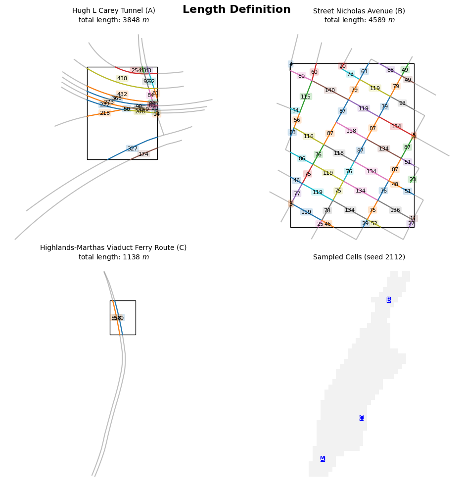

```python
# take three random grid cells
cells = [row.geometry for _, row in GRID.sample(3).iterrows()]

street_name_replacements = {
    'E ': 'East ', 'W ': 'West ', 'N ': 'North ', 'S ': 'South ',
    'St': 'Street', 'Ave': 'Avenue', 'Pl': 'Place', 'Rd': 'Road',
    'Dr': 'Drive', 'Blvd': 'Boulevard', 'Ct': 'Court', 'Ln': 'Lane',
    'Pkwy': 'Parkway', 'Ter': 'Terrace', 'Cir': 'Circle', 'Plz': 'Plaza',
    'Hwy': 'Highway', 'Expy': 'Expressway', 'Brg': 'Bridge', 'Trl': 'Trail',
    'Vyd': 'Viaduct', 'Mnr': 'Manor', 'Tunl': 'Tunnel', 'Rte': 'Route'
}

def plot_cell_streets(ax: plt.Axes, cell_geometry: Polygon, label: str) -> None:
    """ Plot the streets of a grid cell. """

    # create patch object of boundary of cell (cell.exterior.coords)
    ax.add_patch(plt.Polygon(cell_geometry.exterior.coords, facecolor='none', edgecolor='black', linewidth=1, zorder=2))
    ax.set_axis_off()

    # plot the cell's street segments
    streets = STREETS[STREETS.geometry.intersects(cell_geometry)]
    streets.plot(ax=ax, color='grey', alpha=0.5, zorder=1)

    segments = [cell_geometry.intersection(line) for line in streets.geometry]
    distances, centroids = [], []

    colors = [f'C{i}' for i in range(12)]
    ci = 0

    def recurse(segment):
        """ Recursively parse the segments of a MultiLineString. """
        nonlocal ci
        if isinstance(segment, LineString):
            start, end = segment.coords[0], segment.coords[-1]
            distances.append(haversine(start, end))
            centroids.append(((start[0] + end[0]) / 2, (start[1] + end[1]) / 2))
            ax.plot(*zip(*segment.coords), color=colors[ci%12], zorder=3)
            ci += 1
        elif isinstance(segment, MultiLineString):
            # MultiLineString has no coords, but multiple LineStrings which do
            for seg_part in segment.geoms:
                recurse(seg_part)
        else:
            raise ValueError(f'Unexpected type: {type(segment)}, expected LineString or MultiLineString')

    for segment in segments:
        recurse(segment)

    ci = 0
    # show length of each street segment at its midpoint
    for distance, centroid in zip(distances, centroids):
        # distance with transparent colored patch to make text more readable
        ax.text(centroid[0], centroid[1], f'{distance:.0f}', fontsize=8, color='black', ha='center', va='center', zorder=4,
                bbox=dict(facecolor=colors[ci%12], edgecolor='none', alpha=0.2, boxstyle='round, pad=0.2'))
        ci += 1

    # find the street name that occurs most often in the segments
    street_names = streets['full_stree'].value_counts().sort_values(ascending=False).index
    street_name: str = street_names[0].lower().title()
    for abbr, full in street_name_replacements.items():
        street_name = street_name.replace(abbr, full)
    ax.set_title(
        f'{street_name} ({label})\ntotal length: {sum(distances):.0f} $m$',
        fontsize=10, color='black', ha='center', va='center', zorder=5
    )

    return

# create figure object
fig, axes = plt.subplots(2, 2, figsize=(10, 10))
for ax, cell_geometry, label in zip(axes.flatten(), cells, ['A', 'B', 'C']):
    plot_cell_streets(ax, cell_geometry, label)
# plot grid in gray on fourth subplot
GRID.plot(ax=axes[1, 1], color='grey', alpha=0.1, zorder=1)
# plot the three sampled cells in blue
for cell_geometry, label in zip(cells, ['A', 'B', 'C']):
    axes[1, 1].add_patch(plt.Polygon(cell_geometry.exterior.coords, facecolor='blue', edgecolor='blue', linewidth=1, zorder=2))
    x, y = cell_geometry.centroid.coords[0]
    axes[1, 1].text(x, y, label, fontsize=10, color='white', ha='center', va='center', zorder=3)
axes[1, 1].set_title(f'Sampled Cells (seed {seed})', fontsize=10, color='black', ha='center', va='center', zorder=5)
axes[1, 1].set_axis_off()
fig.tight_layout()
fig.subplots_adjust(wspace=0.05, hspace=0.05)
fig.suptitle('Length Definition', fontsize=16, color='black', weight='bold', ha='center', va='center')
fig.savefig(plot_path + 'length_definition.pdf', dpi=500)
```

Here we see that the clipping does indeed work as intended. There is also no overlap between the segments. One shortcoming however is that the segments are calculated by taking the haversine distance between the start and end points of each segment, which is not robust against curvature in the roads. Manhattan's famously grid-like nature minimizes this effect, but it is important to keep in mind.

**Apply to `GRID`**

```python
def get_total_street_length(cell_geometry: Polygon):
    """ Calculate the total length of all street segments within a cell. """

    streets = STREETS[STREETS.geometry.intersects(cell_geometry)]
    segments = [cell_geometry.intersection(line) for line in streets.geometry]
    total_length = 0

    def recurse(segment):
        """ Recursively parse the segments of a MultiLineString. """
        nonlocal total_length
        if isinstance(segment, LineString):
            start, end = segment.coords[0], segment.coords[-1]
            total_length += haversine(start, end)
        elif isinstance(segment, MultiLineString):
            # MultiLineString has no coords, but multiple LineStrings which do
            for seg_part in segment.geoms:
                recurse(seg_part)
        else:
            raise ValueError(f'Unexpected type: {type(segment)}, expected LineString or MultiLineString')

    for segment in segments:
        recurse(segment)

    return total_length

GRID['street_len'] = GRID.geometry.apply(get_total_street_length)
```

**Inspect results**

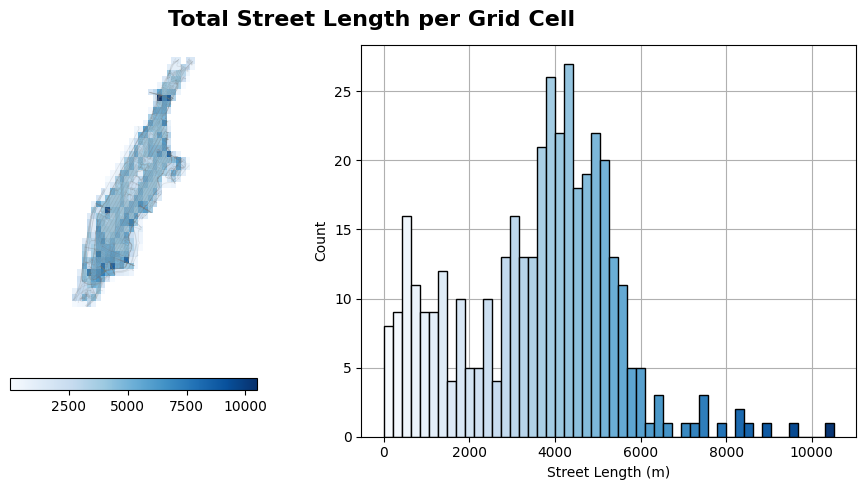

```python
fig, (ax1, ax2) = plt.subplots(1, 2, figsize=(10, 5))

GRID.plot(ax=ax1, column='street_len', cmap='Blues', legend=True, zorder=1, legend_kwds={'orientation': 'horizontal', 'shrink': 0.5})
STREETS.plot(ax=ax1, color='grey', alpha=0.2, linewidth=0.5, zorder=2)
ax1.set_axis_off()

bins = GRID.street_len.hist(ax=ax2, bins=50, color='grey')
for i, patch in enumerate(bins.patches):
    patch.set_facecolor(plt.cm.Blues(i / len(bins.patches)))
    patch.set_edgecolor('black')
ax2.set_axisbelow(True)
ax2.set_xlabel('Street Length (m)')
ax2.set_ylabel('Count')

# fig.set_size_inches(10, 5)
fig.subplots_adjust(wspace=0.05, hspace=0.05)

fig.suptitle('Total Street Length per Grid Cell', fontsize=16, color='black', weight='bold', ha='center', va='center', y=0.95)
fig.tight_layout()
fig.savefig(plot_path + 'total_street_length.pdf', dpi=500)
```

### Tree Distances

**Cell dimensions**

Now that we have the `haversine` function, we can also define the dimension of our grid cells.

```python
cell = GRID.iloc[0].geometry
cell_length = haversine(cell.exterior.coords[0], cell.exterior.coords[1])
cell_width = haversine(cell.exterior.coords[0], cell.exterior.coords[3])
cell_area = cell_length * cell_width
print(f'Cell length: {cell_length:.0f} m, cell width: {cell_width:.0f} m, cell area: {cell_area:.0f} m²')
```

```
Cell length: 556 m, cell width: 422 m, cell area: 234417 m²
```

**Filter data**

Based on the results of the previous section, we can calculate the average distance between two roadside trees in a grid cell by dividing the length of the street segments by the number of trees. A slight problem is that some cells have little to zero trees. This would lead to a division by zero error, or very large numbers that would throw off the scale of our model.

To avoid this, we can set a minimum number of trees per cell, in our case 10. We can justify this by assuming that, if there are less than 10 roadside trees in an area of $0.23 \ \mathrm{km}^2$ (the area of a grid cell), then the area is probably not suitable for planting trees in the first place.

```python
GRID = GRID[GRID.n_trees >= 10]
with warnings.catch_warnings():
    warnings.simplefilter('ignore')
    GRID['tree_dist'] = GRID.apply(lambda row: row['street_len'] / row['n_trees'], axis=1)
```

**Inspect results**

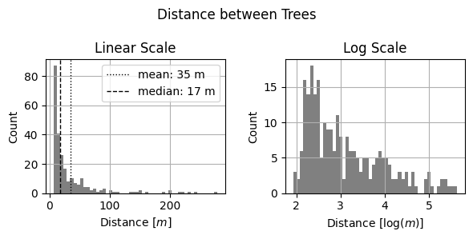

```python
# create column with log of tree distance
with warnings.catch_warnings():
    warnings.simplefilter('ignore')
    GRID['tree_distl'] = np.log(GRID.tree_dist)

fig, (ax1, ax2) = plt.subplots(1, 2, figsize=(6, 3))
GRID.tree_dist.hist(ax=ax1, bins=50, color='grey')
ax1.axvline(mean:=GRID.tree_dist.mean(), color='black', linestyle='dotted', linewidth=1, label=f'mean: {mean:.0f} m')
ax1.axvline(median:=GRID.tree_dist.median(), color='black', linestyle='dashed', linewidth=1, label=f'median: {median:.0f} m')
ax1.set_xlabel('Distance $[m]$')
ax1.set_ylabel('Count')
ax1.legend()
ax1.set_title('Linear Scale')

GRID.tree_distl.hist(ax=ax2, bins=50, color='grey')
ax2.set_xlabel('Distance $[\log(m)]$')
ax2.set_ylabel('Count')
ax2.set_title('Log Scale')

fig.suptitle('Distance between Trees')
fig.tight_layout()
```

Secondly, it should be very interesting to see the data plotted on the map. We also show the attributes that are used to calculate these values. Here, we also use the logarithm of the distances for a more clear visualization.

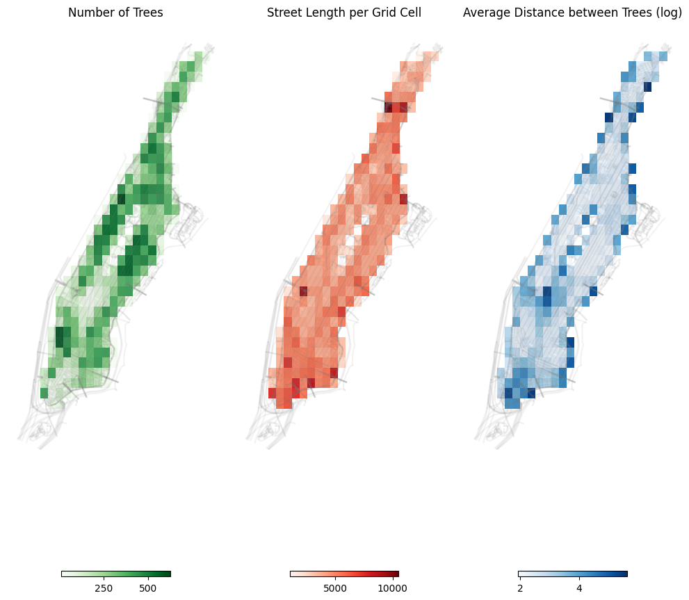

```python
fig, axes = plt.subplots(1, 3, figsize=(10, 10))
for ax, col, cmap in zip(axes, ['n_trees', 'street_len', 'tree_distl'], ['Greens', 'Reds', 'Blues']):
    GRID.plot(ax=ax, column=col, cmap=cmap, legend=True, legend_kwds={'orientation': 'horizontal', 'shrink': 0.5}, zorder=1)
    STREETS.plot(ax=ax, color='grey', alpha=0.1, zorder=2)
    ax.set_axis_off()
    ax.set_title(titles[col])
fig.tight_layout()
fig.subplots_adjust(wspace=0.05, hspace=0.05)
fig.savefig(plot_path + 'tree_distance1.pdf', dpi=500)
```

For completeness, we also plot the actual distances on the map.

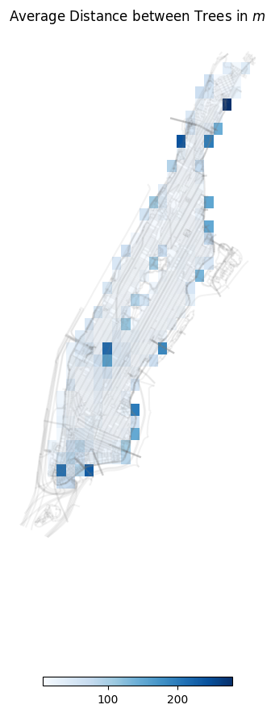

```python
fig, ax = plt.subplots(figsize=(5, 10))
GRID.plot(ax=ax, column='tree_dist', cmap='Blues', legend=True, legend_kwds={'orientation': 'horizontal', 'shrink': 0.5}, zorder=1)
STREETS.plot(ax=ax, color='grey', alpha=0.1, zorder=2)
ax.set_axis_off()
ax.set_title('Average Distance between Trees in $m$')
fig.tight_layout()
fig.subplots_adjust(wspace=0.05, hspace=0.05)
fig.savefig(plot_path + 'tree_distance2.pdf', dpi=500)
```

### Traffic Volume Interpolation

**Define Data Points**

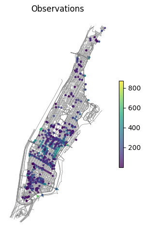

```python
x, y = TRAFFIC.geometry.x.values, TRAFFIC.geometry.y.values
phi = TRAFFIC.Avg_Vol.values

assert x.shape[0] == y.shape[0] == phi.shape[0]

fig, ax = plt.subplots(figsize=(4, 5))
STREETS.plot(ax=ax, color='gray', linewidth=0.5, zorder=1)
cax = ax.scatter(x, y, c=phi, cmap='viridis', s=5, alpha=0.75, zorder=2)
ax.set_title('Observations')
ax.set_axis_off()
fig.colorbar(cax, ax=ax, shrink=0.4)
fig.tight_layout()
```

**Interpolate with Ordinary Kriging**

```python
OK = OrdinaryKriging(x, y, phi, variogram_model='exponential', verbose=False, enable_plotting=False)
minx, miny, maxx, maxy = GRID.total_bounds
X = np.arange(minx, maxx, 0.005)
Y = np.arange(miny, maxy-0.005, 0.005)
zstar, ss = OK.execute('grid', X, Y)
```

**Inspect results**

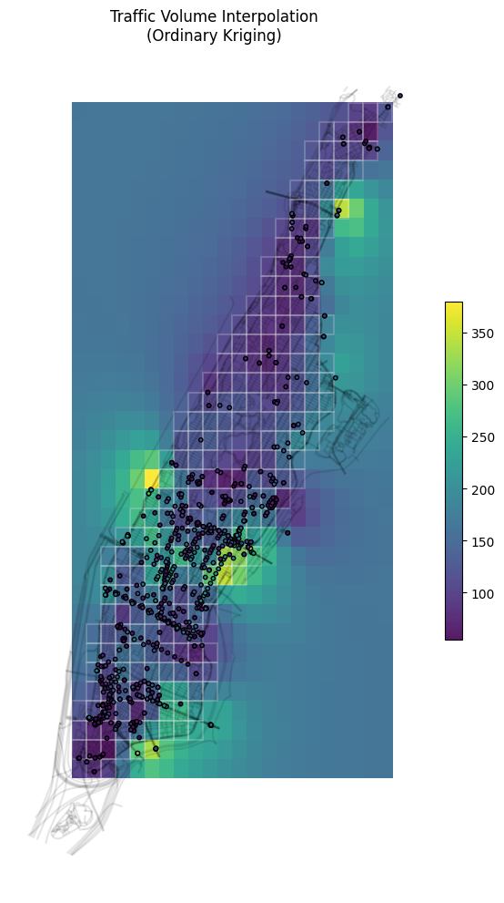

```python
fig, ax = plt.subplots(figsize=(6, 10))
cax = ax.imshow(
    zstar,
    extent = (minx, maxx, miny, maxy),
    cmap = 'viridis',
    origin = 'lower',
    alpha = 0.9,
    zorder = 1
)
STREETS.plot(ax=ax, color='k', alpha=0.1, zorder=2)
for i, row in GRID.iterrows():
    x_, y_ = row.geometry.exterior.xy
    ax.plot(x_, y_, color='w', alpha=0.2, zorder=3)
ax.scatter(x, y, c=phi, cmap='viridis', edgecolors='k', s=10, zorder=3)
ax.set_axis_off()
ax.set_title('Traffic Volume Interpolation\n(Ordinary Kriging)')
fig.colorbar(cax, ax=ax, shrink=0.4)
fig.tight_layout()
fig.savefig(plot_path + 'ordinary_kriging.pdf', dpi=500)
```

The interpolated grid only covers a portion of the study area due to the selective trimming of the original data where we discarded grid cells with less than 10 trees. In order to illustrate what traffic data we are left with, we also trim the interpolated traffic volume grid to the same area and plot it next to the averages we previously calculated.

**Add to `GRID`**

```python
GRID['trfc_itp'] = np.nan
for i, row in GRID.iterrows():
    x_, y_ = row.geometry.exterior.xy
    x_idx = np.argmin(np.abs(X - x_[0]))
    y_idx = np.argmin(np.abs(Y - y_[0]))
    GRID.loc[i, 'trfc_itp'] = zstar[y_idx, x_idx]
```

**Visualize**

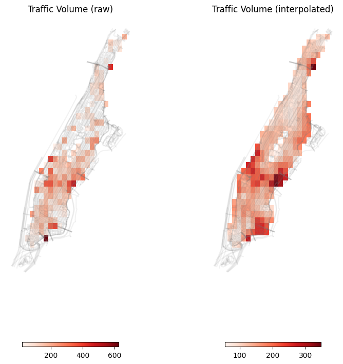

```python
fig, axes = plt.subplots(1, 2, figsize=(8, 8))
for ax, col, cmap in zip(axes, ['trfc_raw', 'trfc_itp'], ['Reds', 'Reds']):
    GRID.plot(ax=ax, column=col, cmap=cmap, legend=True, legend_kwds={'orientation': 'horizontal', 'shrink': 0.5}, zorder=1)
    STREETS.plot(ax=ax, color='grey', alpha=0.1, zorder=2)
    ax.set_axis_off()
    ax.set_title(titles[col])
fig.tight_layout()
fig.subplots_adjust(wspace=0.05, hspace=0.05)
fig.savefig(plot_path + 'traffic_interpolation.pdf', dpi=500)
```

**Save `GRID`**

```python
target_path = shp_path + 'grid' + os.sep + 'M_grid.shp'
with warnings.catch_warnings():
    # some column names will be truncated, but it's no big deal
    warnings.simplefilter('ignore')
    GRID.to_file(target_path)
```